# **secr** simulations LDF

Murray Efford

2024-06-14

# Latent Detection Field LDF

The simulations described here are part of a series documenting the effect of breaching assumptions of spatially explicit capture–recapture models.

Stevenson et al. (2021) proposed a framework for spatial variation in detection probability that incorporates both individual heterogeneity and spatial (detector-specific) variation in detection conditional on AC. Log detection hazard at the $K$ detectors is modelled as multivariate normal, with a covariance structure such as
$$\sum_{jj'} = \sigma_u^2 \exp\{-d(\vec
x_j), \vec x_{j'})/\rho^2\}$$
where $\sigma_u^2$ is the marginal variance and $\rho$ determines the spatial scale of correlation among detectors.

| Case | Label | Interpretation |
| --- | --- | --- |
| $\sigma_u = 0$ | Special case I, “none” | no heterogeneity, individuals or detectors |
| $\sigma_u > 0, \rho = 0$ | Special case II, “independent”, “overdispersed” | overdispersed detections per detector |
| $\sigma_u > 0, \rho \to \infty$ | Special Case III, “individual” | individual heterogeneity |

The primary scenarios considered by Stevenson et al. (2021) and Moqanaki et al. (2021) differed as follows:

| Variable | Moqanaki et al. (2021) | Dey et al (2023) | Stevenson et al. (2021) |
| --- | --- | --- | --- |
| detections | binary (Bernoulli) | binary (Bernoulli) | Poisson |
| occasions | 1 | 1 | 1 |
| grid | large 20 x 20 | larger 32 x 32 | small paired 4 x 4 |
| method | data augmentation | data augmentation | MLE |
| model | probability | probability | hazard |
| parameters | $\phi, \beta_0, \beta_X, \sigma$ | $\phi, \eta = g_0, \sigma$ | $\sigma_u, \rho, \lambda_0, \sigma$ |
| auto-covariance | ~sq-exponential | exponential | sq-exponential |
|  | $\sum_{jj'} = \exp\{-\phi \, d(\vec x_j, \vec x_{j'}) \}$ | $\sum_{jj'} = \exp\{-\phi \, d(\vec x_j, \vec x_{j'}) \}$ | $\sum_{jj'} = \sigma_u^2 \exp\{-d(\vec x_j, \vec x_{j'})^2/\rho^2\}$ |
| random effect | $X \sim \mbox{MVN}(0,\Sigma)$, $p_{ij} = \mbox{logit}^{-1}(\beta_0 + \beta_{\vec X} \vec X_j) f(d_{ij})$ | $X \sim \mbox{MVN}(\mbox{logit}(\eta),\Sigma)$, $p_{ij} = \mbox{logit}^{-1}(\vec X_j) f(d_{ij})$ | $X \sim \mbox{MVN}(0,\Sigma))$ , $\lambda_{ij} = \lambda_0 \exp(X_{ij}) f(d_{ij})$ |
| continuous/categorical | both | both | continuous |
| individual effect | no | no | yes |
| scaled | X? | no | no |
| pattern validation | Moran’s I | none | none |

## Problem description

We wish to reproduce the simulation results of Stevenson et al. (2021) for a range of values of $\sigma_u$ and $\rho$, and extend them to the case that the LDF is shared across individuals.

## Package version, date and platform

```r
source('../setup.R')
runsim  <- FALSE
figures <- TRUE
cache   <- TRUE
nrepl   <- 100
nrepl2  <- 500
metadata(runsim) # if FALSE picks up saved metadata.RDS
```

```
## R version 4.3.2 (2023-10-31)
## Platform   x86_64-pc-linux-gnu (64-bit)
## Running    CentOS Linux 7 (Core)
## secr       4.6.7 2024-05-18
## secrdesign 2.9.2 2024-05-18
## Threads    40
## Run        Tue Jun 11 13:57:51 2024
```

## Simulation code

We assume a single occasion.

```r
simLDF.capthist <- function (traps, popn, detectfn, detectpar, noccasions = 1,
                             cov.structure, sigma.u, rho, adjustmu = TRUE, shared = FALSE, ...)
{
    K <- nrow(traps)
    N <- nrow(popn)
    ac.dists   <- secr::edist(popn, traps)     # activity centres to traps
    trap.dists <- secr::edist(traps,traps)     # between traps
    # "baseline" encounter rates
    if (detectfn == 14 || detectfn == "HHN"){
        base.er <- detectpar$lambda0*exp(-ac.dists^2/(2*detectpar$sigma^2))
    }
    else if (detectfn == 16 || detectfn == "HEX"){
        base.er <- detectpar$lambda0*exp(-ac.dists/detectpar$sigma)
    }
    else stop ("detectfn not implemented")

    ## Constructing covariance matrix
    # adjust mu.u so E(exp(u.mat[i,j])) = 1.0
    if (adjustmu)
        mu.u <- - sigma.u^2 / 2
    else
        mu.u <- 0
    if (cov.structure == "none"){
        cov <- matrix(0, nrow = K, ncol = K)
    }
    else if (cov.structure == "independent"){    # rho = 0
        cov <- diag(sigma.u^2, K, K)
    }
    else if (cov.structure == "exponential"){
        cov <- sigma.u^2*exp(-trap.dists/rho)
    }
    else if (cov.structure == "individual"){     # rho > infty
        cov <- matrix(sigma.u^2, nrow = K, ncol = K)
    }
    else if (cov.structure == "sq_exponential"){
        cov <- sigma.u^2*exp(-(trap.dists^2)/(rho^2))
    }
    ## Simulate random field (individual x detector)
    if (shared) {
        u.row <- mvtnorm::rmvnorm(1, mean = rep(mu.u, K), sigma = cov)
        u.mat <- matrix(rep(u.row,N), byrow = TRUE, nrow = N)
    }
    else {
        u.mat <- mvtnorm::rmvnorm(N, mean = rep(mu.u, K), sigma = cov)
    }
    full.er <- base.er * exp(u.mat) # encounter rates
    if (noccasions>1) {
        # replicate occasions
        full.er <- aperm(apply(full.er,1:2,rep,noccasions), c(2,1,3))
    }
    if (detector(traps)[1] == 'proximity') {
        ch <- rbinom(N*K*noccasions, 1, 1-exp(-full.er))
    }
    else if (detector(traps)[1] == 'count') {
        ch <- rpois(N*K*noccasions, full.er)
    }
    else stop ("detector not proximity or count")
    ch <- array(ch, dim=c(N,noccasions,K))
    rownames(ch) <- 1:N
    ch <- ch[apply(ch, 1, function(x) sum(x) > 0),,, drop = FALSE]
    class(ch) <- 'capthist'
    traps(ch) <- traps
    attr(ch, 'u.mat') <- u.mat
    ch
}
```

```r
# These are the detector sites used by Ben Stevenson (2021)
trps <- make.grid(4,4,detector = 'count', spacing = 100)
trps <- rbind(trps,trps)
trps$x <- trps$x + rep(c(-10,10), c(16,16))
msk    <- make.mask(trps, buffer = 500, type = 'trapbuffer')
```

```r
detarg <- expand.arg(sigma.u = seq(0,1.6,0.4), rho = c(50,150,450),
                        cov.structure = "sq_exponential", noccasions = 1)
poparg <- list(buffer = 500)
fitarg <- list(detectfn = 'HHN', mask = msk)
scen   <- make.scenarios(D = 1, lambda0 = 0.5, sigma = 100,  detectfn = 'HHN',
                         detindex = 1:length(detarg))
```

```r
LDFsims <- run.scenarios(
    nrepl       = nrepl,
    scenarios   =  scen,
    trapset     = trps,
    CH.function = "simLDF.capthist",
    pop.args    = poparg,
    det.args    = detarg,
    fit         = TRUE,
    fit.args    = fitarg)
saveRDS(LDFsims, file = 'LDFsims.RDS')
```

```r
detarg <- expand.arg(sigma.u = seq(0,1.6,0.4), rho = c(50,150,450),
                cov.structure = "sq_exponential", shared = TRUE, noccasions = 1)
poparg <- list(buffer = 500)
fitarg <- list(detectfn = 'HHN', mask = msk)
scen   <- make.scenarios(D = 1, lambda0 = 0.5, sigma = 100,  detectfn = 'HHN',
                         detindex = 1:length(detarg))
```

```r
scenarioSummary(scen, trapset = trps)
```

```
##    scenario trapsindex noccasions nrepeats D lambda0 sigma detectfn     En     Er     Em    En2
## 1         1          1          3        1 1     0.5   100       14 48.532 253.05 230.86 36.049
## 2         2          1          3        1 1     0.5   100       14 48.532 253.05 230.86 36.049
## 3         3          1          3        1 1     0.5   100       14 48.532 253.05 230.86 36.049
## 4         4          1          3        1 1     0.5   100       14 48.532 253.05 230.86 36.049
## 5         5          1          3        1 1     0.5   100       14 48.532 253.05 230.86 36.049
## 6         6          1          3        1 1     0.5   100       14 48.532 253.05 230.86 36.049
## 7         7          1          3        1 1     0.5   100       14 48.532 253.05 230.86 36.049
## 8         8          1          3        1 1     0.5   100       14 48.532 253.05 230.86 36.049
## 9         9          1          3        1 1     0.5   100       14 48.532 253.05 230.86 36.049
## 10       10          1          3        1 1     0.5   100       14 48.532 253.05 230.86 36.049
## 11       11          1          3        1 1     0.5   100       14 48.532 253.05 230.86 36.049
## 12       12          1          3        1 1     0.5   100       14 48.532 253.05 230.86 36.049
## 13       13          1          3        1 1     0.5   100       14 48.532 253.05 230.86 36.049
## 14       14          1          3        1 1     0.5   100       14 48.532 253.05 230.86 36.049
```

[output cut: 17 more lines]

```r
LDFsimsshared <- run.scenarios(
    nrepl       = nrepl,
    scenarios   = scen,
    trapset     = trps,
    CH.function = "simLDF.capthist",
    pop.args    = poparg,
    det.args    = detarg,
    fit         = TRUE,
    fit.args    = fitarg)
saveRDS(LDFsimsshared, file = 'LDFsimsshared.RDS')
```

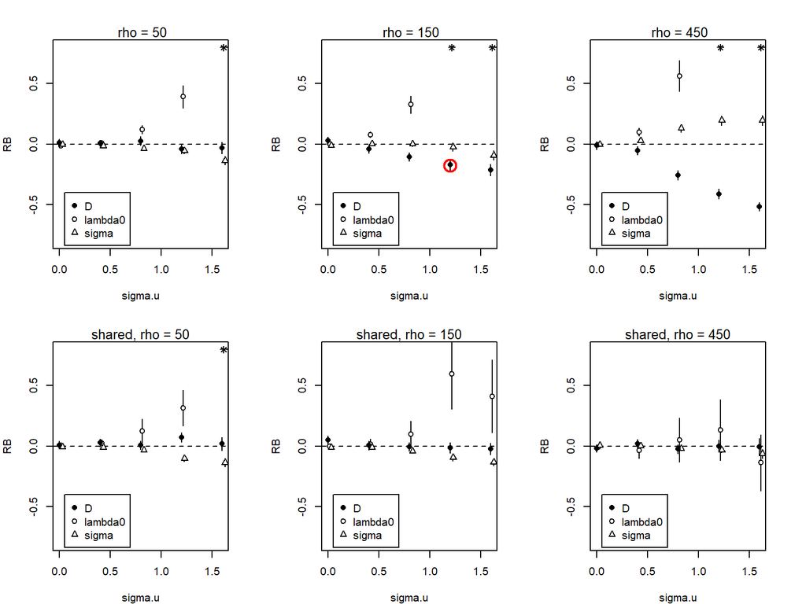

```r
parm <- do.call(rbind, lapply(detarg, as.data.frame))   # now flat
estD <- estimateSummary(LDFsims, 'D', validrange = c(0,10))
estL <- estimateSummary(LDFsims, 'lambda0', validrange = c(0,5))
estS <- estimateSummary(LDFsims, 'sigma', validrange = c(0,1000))
estDs <- estimateSummary(LDFsimsshared, 'D', validrange = c(0,10))
estLs <- estimateSummary(LDFsimsshared, 'lambda0', validrange = c(0,5))
estSs <- estimateSummary(LDFsimsshared, 'sigma', validrange = c(0,1000))
leg <- c('D','lambda0','sigma')

plotone <- function (estD,estL,estS, shared, rho) {
    plot(0,0, type = 'n', xlim=c(0,1.6), xlab = 'sigma.u', ylab = 'RB', ylim=c(-0.8,0.8))
    abline(h=0, lty=2)
    rows <- parm$rho == rho
    addRB(parm$sigma.u[rows], estL[rows,], pch=21, bg='white', star = 0.8, xoffset=0.015)
    addRB(parm$sigma.u[rows], estS[rows,], pch=24, bg='white', star = 0.8, xoffset=0.03)
    addRB(parm$sigma.u[rows], estD[rows,], pch=16)
    mtext(side=3, paste0(shared, ' rho = ', rho), cex=0.8)
    legend(0.05, -0.4, legend=leg, pch=c(16,21,24))
}

par(mfrow=c(2,3), mar=c(4,4,3,3))

plotone(estD,estL,estS, shared = '', rho = 50)
plotone(estD,estL,estS, shared = '', rho = 150)
points(1.2, -0.18, pch=1, cex=2.5, lwd=2,col='red') # Ben's result
plotone(estD,estL,estS, shared = '', rho = 450)

plotone(estDs,estLs,estSs, shared = 'shared,', rho = 50)
plotone(estDs,estLs,estSs, shared = 'shared,', rho = 150)
plotone(estDs,estLs,estSs, shared = 'shared,', rho = 450)
```

## Interpretation

# Hooten et al. 2024 GCR

Hooten et al. (2024) simulated data for animals with multinuclear home ranges and applied a Gaussian latent detection field model to a single dataset. We generate similar data and apply the null SECR estimator.

## Alternative capthist simulator

`simGCR.capthist` uses the popn argument only to indicate the number of individuals and the buffered region. New random uniform centres are generated internally for each of the N individuals. The number of centres per individual is a truncated Poisson random variable, with rate parameter AClam. The probability an individual is detected in a particular detector is determined by the distance to its nearest activity centre (i.e. the maximum of the detection function over all activity centres).

```r
simGCR.capthist <- function (traps, popn, detectfn, detectpar, noccasions, AClam = 0.5) {
    oneanimal <- function (ACs) {
        d <- edist(ACs, traps)
        d <- apply(d,2,min)   # probability determined by closest AC to detector
        lam0 <- exp(alpha + beta * d^2)
        p <- 1 - exp (-lam0)
        p <- matrix(rep(p, noccasions), nrow = noccasions, ncol = K, byrow = TRUE)
        (runif(K*noccasions)<p) * 1.0
    }
    if (!(detectfn ==14 || detectfn == 'HHN'))
        stop ("simGCR.capthist assumes detectfn = 'HHN'")

    N <- nrow(popn)
    K     <- nrow(traps)
    buffer <-  min(traps$x) - min(attr(popn, 'boundingbox')$x)
    alpha <- log(detectpar$lambda0)
    beta  <- -1/2/detectpar$sigma^2   # -50 for sigma = 0.1

    # number of centres per animal
    nAC <- secr:::rtpois(N,AClam)

    # randomly locate centres of each animal within buffered region
    allACs <- lapply(nAC, function(nc) sim.popn(Nbuffer = nc, core = traps,
         buffer = buffer, Ndist = 'fixed'))

    # construct detection probabilities and sample
    ch  <- lapply(allACs, oneanimal)

    # form capthist object, saving centres as an attribute
    ch  <- array(do.call(c, ch), dim = c(N,noccasions,K))
    rownames(ch) <- 1:N
    detected <- apply(ch,1,sum)>0
    ch <- ch[detected,,, drop = FALSE]
    class(ch) <- 'capthist'
    traps(ch) <- traps
    attr(ch,'allACs') <- allACs
    attr(ch, 'detected') <- detected
    ch
}
```

```r
grid64 <- make.grid(nx = 8, ny = 8, spacing = 1/7, detector = 'proximity')
mask64 <- make.mask(grid64, buffer = 0.5)
```

## Illustration

Simulating (potentially) multiple centres per animal across the mask results in very wide ‘movements’.

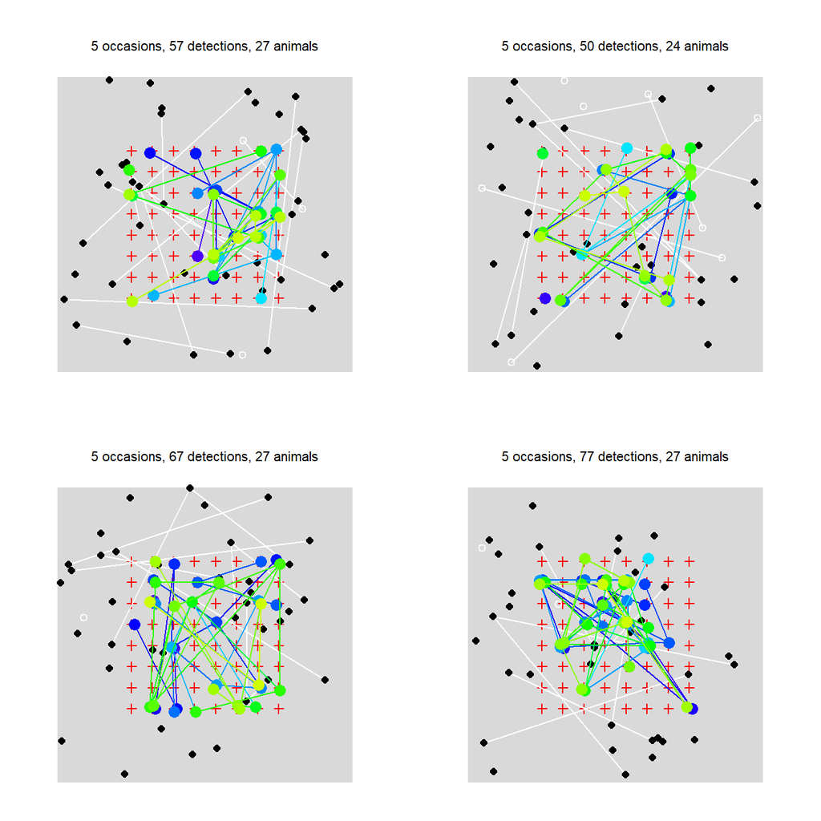

Figure: Simulated multinuclear data (centres joined by white line if more than one per animal). Detected animals: filled circles, undetected animals: white open circles. Detection data overlaid in colour.

```r
pop <- sim.popn(core = grid64, buffer = 0.5, Nbuffer = 29, Ndist = "fixed")
plotone <- function(r, ...) {
    plot(mask64, border=0.1, dots=F, col=grey(0.85))
    plot(grid64, add = TRUE)
    ch <- simGCR.capthist(...)
    allACs <- attr(ch, 'allACs')
    detACs <- allACs[attr(ch, 'detected')]
    junk <- lapply(allACs, points, type='o', col='white', pch=1)
    junk <- lapply(detACs, points, type='p', pch=16)
    plot(ch, rad=0.02, border=0.5, tracks = TRUE, title='', add = TRUE)
}
par(mfrow=c(2,2), mar = c(1,1,3,1))
junk <- sapply(1:4, plotone, traps = grid64, popn = pop, detectfn = 'HHN', noccasions = 5,
       detectpar = list(lambda0 = exp(-1), sigma = 0.1))
```

## Run simulations

```r
poparg <- list(buffer = 0.5, Ndist = "fixed")
detarg <- list(AClam = 0.5)
fitarg <- list(detectfn = 'HHN', details = list(distribution = "binomial"))
scen   <- make.scenarios(D = 29/maskarea(mask64), lambda0 = exp(-1), sigma = 0.1,
        detectfn = 'HHN', detindex = 1:length(detarg), noccasions = 5)
```

```r
GCRsims <- run.scenarios(
    nrepl       = nrepl2,
    scenarios   = scen,
    trapset     = grid64,
    maskset     = mask64,
    CH.function = "simGCR.capthist",
    pop.args    = poparg,
    det.args    = detarg,
    fit         = TRUE,
    fit.args    = fitarg)
saveRDS(GCRsims, file = 'GCRsims.RDS')
```

## Results

```r
GCRsims <- readRDS(file = 'GCRsims.RDS')
```

```r
estD <- estimateSummary(GCRsims, 'D')
estL <- estimateSummary(GCRsims, 'lambda0')
estS <- estimateSummary(GCRsims, 'sigma')
estlist <- list(estD,estL,estS)
estlist <- lapply(estlist, function(x) {names(x)[2] <- 'true';x})
tmp <- do.call(rbind, estlist)
cbind(parameter = c('D','lambda0','sigma'), tmp[,-1])
```

```
##   parameter       true nvalid        EST      seEST          RB       seRB      RSE       RMSE
## 1         D 7.2500e+04    100 7.4845e+04 8.1626e+02  3.2341e-02 1.1259e-02 0.097883 8453.37163
## 2   lambda0 3.6788e-01     99 3.2631e-02 8.9818e-03 -9.1130e-01 2.4415e-02 0.306530    0.34684
## 3     sigma 1.0000e-01     95 1.9289e+03 8.4950e+02  1.9288e+04 8.4950e+03      Inf 8459.08522
##        rRMSE      COV
## 1 1.1660e-01 0.990000
## 2 9.4281e-01 0.070707
## 3 8.4591e+04 0.210526
```

Negligible bias in $\hat D$ but wild bias in $\hat \lambda_0$ and $\hat \sigma$.